# Predicting Airbnb Price

## - based on Seattle, Boston Airbnb Datasets

This project will adhere to **CRISP-DM**(Cross Industry Process for Data Mining) Process which includes the following steps:

> 1. Business Understanding
> 2. Data Understanding
> 3. Prepare Data
> 4. Model data
> 5. Results.
> 6. Deploy

# 1. Business Understanding

From a business standpoint, we would like to understand how rental prices for Airbnb properties are set. Therefore, we want to build a model that learns on Seattle and Boston Airbnb datasets and predict the price. To this end, one might want to ask the following questions:

```
- Q1. Is there a difference in price in two cities?
- Q2. How many Airbnb properties are hosted by the same host on average?
- Q3. How does price spread based on location - is it evenly distributed or unevenly?
- Q4. What are the most important predictors for the price?
```

# 2. Data Understanding

You can find data for [Seattle](https://www.kaggle.com/airbnb/seattle/data) and [Boston](https://www.kaggle.com/airbnb/boston) at Kaggle.

```python
%matplotlib inline

import pandas as pd
import numpy as np
from os import path, getcwd
import matplotlib.pyplot as plt
import seaborn as sns
from sklearn.impute import SimpleImputer
from ast import literal_eval
from sklearn.preprocessing import StandardScaler
import warnings
## helper.py has all modularized process functions - preprocessing, training
from helper import preprocessor, model_data, predict_model
import xgboost as xgb
from sklearn.metrics import r2_score, mean_squared_error, explained_variance_score
from sklearn.model_selection import GridSearchCV, train_test_split

warnings.filterwarnings('ignore')
sns.set(style='whitegrid', rc={"lines.linewidth":2, 'grid.color': '.8', 'grid.linestyle':':'})
```

```python
# ## **** You can run this code block if you want to proceed all at once ****

# ## Load data & preprocess data
# sea_df, bos_df, sea_df_nostd, bos_df_nostd = preprocessor()

# ## Train model
# xgb_reg, X_train, X_test, y_train, y_test = model_data(sea_df, bos_df, random_state=77)

# ## Predict responses.
# preds, rmse = predict_model(xgb_reg, X_test, y_test, show=False, number=10)
```

```python
## read files
cities = ['seattle', 'boston']
# retrieve current directory
cwd = path.join(getcwd(), 'data')

## Read files to data frames
sea_df = pd.read_csv(path.join(cwd, cities[0], 'listings.csv'), parse_dates=['last_scraped', 'first_review', 'last_review', 'host_since'])
bos_df = pd.read_csv(path.join(cwd, cities[1], 'listings.csv'), parse_dates=['last_scraped', 'first_review', 'last_review', 'host_since'])
```

```python
sea_df.shape, bos_df.shape
```

```
((3818, 92), (3585, 95))
```

Notice feature numbers differ.

```python
## Unify columns
bos_df = bos_df[sea_df.columns]
```

```python
## Display first few rows
sea_df.head(3)
```

|  | id | listing_url | scrape_id | last_scraped | name | summary | space | description | experiences_offered | neighborhood_overview | ... | review_scores_value | requires_license | license | jurisdiction_names | instant_bookable | cancellation_policy | require_guest_profile_picture | require_guest_phone_verification | calculated_host_listings_count | reviews_per_month |
| --- | --- | --- | --- | --- | --- | --- | --- | --- | --- | --- | --- | --- | --- | --- | --- | --- | --- | --- | --- | --- | --- |
| 0 | 241032 | https://www.airbnb.com/rooms/241032 | 20160104002432 | 2016-01-04 | Stylish Queen Anne Apartment | NaN | Make your self at home in this charming one-be... | Make your self at home in this charming one-be... | none | NaN | ... | 10.0 | f | NaN | WASHINGTON | f | moderate | f | f | 2 | 4.07 |
| 1 | 953595 | https://www.airbnb.com/rooms/953595 | 20160104002432 | 2016-01-04 | Bright & Airy Queen Anne Apartment | Chemically sensitive? We've removed the irrita... | Beautiful, hypoallergenic apartment in an extr... | Chemically sensitive? We've removed the irrita... | none | Queen Anne is a wonderful, truly functional vi... | ... | 10.0 | f | NaN | WASHINGTON | f | strict | t | t | 6 | 1.48 |
| 2 | 3308979 | https://www.airbnb.com/rooms/3308979 | 20160104002432 | 2016-01-04 | New Modern House-Amazing water view | New modern house built in 2013. Spectacular s... | Our house is modern, light and fresh with a wa... | New modern house built in 2013. Spectacular s... | none | Upper Queen Anne is a charming neighborhood fu... | ... | 10.0 | f | NaN | WASHINGTON | f | strict | f | f | 2 | 1.15 |

3 rows × 92 columns

```python
bos_df.head(3)
```

|  | id | listing_url | scrape_id | last_scraped | name | summary | space | description | experiences_offered | neighborhood_overview | ... | review_scores_value | requires_license | license | jurisdiction_names | instant_bookable | cancellation_policy | require_guest_profile_picture | require_guest_phone_verification | calculated_host_listings_count | reviews_per_month |
| --- | --- | --- | --- | --- | --- | --- | --- | --- | --- | --- | --- | --- | --- | --- | --- | --- | --- | --- | --- | --- | --- |
| 0 | 12147973 | https://www.airbnb.com/rooms/12147973 | 20160906204935 | 2016-09-07 | Sunny Bungalow in the City | Cozy, sunny, family home. Master bedroom high... | The house has an open and cozy feel at the sam... | Cozy, sunny, family home. Master bedroom high... | none | Roslindale is quiet, convenient and friendly. ... | ... | NaN | f | NaN | NaN | f | moderate | f | f | 1 | NaN |
| 1 | 3075044 | https://www.airbnb.com/rooms/3075044 | 20160906204935 | 2016-09-07 | Charming room in pet friendly apt | Charming and quiet room in a second floor 1910... | Small but cozy and quite room with a full size... | Charming and quiet room in a second floor 1910... | none | The room is in Roslindale, a diverse and prima... | ... | 9.0 | f | NaN | NaN | t | moderate | f | f | 1 | 1.30 |
| 2 | 6976 | https://www.airbnb.com/rooms/6976 | 20160906204935 | 2016-09-07 | Mexican Folk Art Haven in Boston | Come stay with a friendly, middle-aged guy in ... | Come stay with a friendly, middle-aged guy in ... | Come stay with a friendly, middle-aged guy in ... | none | The LOCATION: Roslindale is a safe and diverse... | ... | 10.0 | f | NaN | NaN | f | moderate | t | f | 1 | 0.47 |

3 rows × 92 columns

```python
sea_df.columns
```

```
Index(['id', 'listing_url', 'scrape_id', 'last_scraped', 'name', 'summary',
       'space', 'description', 'experiences_offered', 'neighborhood_overview',
       'notes', 'transit', 'thumbnail_url', 'medium_url', 'picture_url',
       'xl_picture_url', 'host_id', 'host_url', 'host_name', 'host_since',
       'host_location', 'host_about', 'host_response_time',
       'host_response_rate', 'host_acceptance_rate', 'host_is_superhost',
       'host_thumbnail_url', 'host_picture_url', 'host_neighbourhood',
       'host_listings_count', 'host_total_listings_count',
       'host_verifications', 'host_has_profile_pic', 'host_identity_verified',
       'street', 'neighbourhood', 'neighbourhood_cleansed',
       'neighbourhood_group_cleansed', 'city', 'state', 'zipcode', 'market',
       'smart_location', 'country_code', 'country', 'latitude', 'longitude',
       'is_location_exact', 'property_type', 'room_type', 'accommodates',
       'bathrooms', 'bedrooms', 'beds', 'bed_type', 'amenities', 'square_feet',
       'price', 'weekly_price', 'monthly_price', 'security_deposit',
       'cleaning_fee', 'guests_included', 'extra_people', 'minimum_nights',
       'maximum_nights', 'calendar_updated', 'has_availability',
       'availability_30', 'availability_60', 'availability_90',
       'availability_365', 'calendar_last_scraped', 'number_of_reviews',
       'first_review', 'last_review', 'review_scores_rating',
       'review_scores_accuracy', 'review_scores_cleanliness',
       'review_scores_checkin', 'review_scores_communication',
       'review_scores_location', 'review_scores_value', 'requires_license',
       'license', 'jurisdiction_names', 'instant_bookable',
       'cancellation_policy', 'require_guest_profile_picture',
       'require_guest_phone_verification', 'calculated_host_listings_count',
       'reviews_per_month'],
      dtype='object')
```

```python
## hand-pick features of interest
cols = ['id', 'host_id', 'host_since', 'host_verifications', 'host_is_superhost', 'zipcode', 'bathrooms', 'bedrooms',
        'beds', 'bed_type', 'amenities', 'square_feet', 'price', 'weekly_price', 'monthly_price', 'security_deposit',
        'cleaning_fee', 'guests_included', 'extra_people', 'minimum_nights','maximum_nights', 'calendar_updated',
        'has_availability', 'availability_30', 'availability_60', 'availability_90', 'availability_365',
        'number_of_reviews', 'first_review', 'last_review', 'review_scores_rating','review_scores_accuracy',
        'review_scores_cleanliness', 'review_scores_checkin', 'review_scores_communication', 'review_scores_location',
        'review_scores_value', 'instant_bookable', 'cancellation_policy', 'require_guest_profile_picture',
        'require_guest_phone_verification','calculated_host_listings_count', 'reviews_per_month']

sea_df = sea_df[cols]
bos_df = bos_df[cols]
```

# 3. Prepare Data

```python
## check columns with missings in sea_df
temp1 = sea_df.isnull().sum()/sea_df.shape[0]
temp1[temp1 > 0]
```

```
host_since                     0.000524
host_is_superhost              0.000524
zipcode                        0.001833
bathrooms                      0.004191
bedrooms                       0.001572
beds                           0.000262
square_feet                    0.974594
weekly_price                   0.473808
monthly_price                  0.602672
security_deposit               0.511262
cleaning_fee                   0.269775
first_review                   0.164222
last_review                    0.164222
review_scores_rating           0.169460
review_scores_accuracy         0.172342
review_scores_cleanliness      0.171032
review_scores_checkin          0.172342
review_scores_communication    0.170508
review_scores_location         0.171556
review_scores_value            0.171818
reviews_per_month              0.164222
dtype: float64
```

```python
## check columns with missings in bos_df
temp2 = bos_df.isnull().sum() / bos_df.shape[0]
temp2[temp2 > 0]
```

```
zipcode                        0.010600
bathrooms                      0.003905
bedrooms                       0.002789
beds                           0.002510
square_feet                    0.984379
weekly_price                   0.751185
monthly_price                  0.752301
security_deposit               0.625662
cleaning_fee                   0.308787
has_availability               1.000000
first_review                   0.210879
last_review                    0.210879
review_scores_rating           0.226778
review_scores_accuracy         0.229568
review_scores_cleanliness      0.228173
review_scores_checkin          0.228731
review_scores_communication    0.228173
review_scores_location         0.229289
review_scores_value            0.229010
reviews_per_month              0.210879
dtype: float64
```

```python
## Let us drop features with more than 20% missings
sea_df = sea_df.drop(columns=temp2[temp2>.2].index.values)
bos_df = bos_df.drop(columns=temp2[temp2>.2].index.values)
```

```python
sea_df.shape, bos_df.shape
```

```
((3818, 27), (3585, 27))
```

```python
temp1 = sea_df.isnull().sum()
temp1[temp1 > 0]
```

```
host_since            2
host_is_superhost     2
zipcode               7
bathrooms            16
bedrooms              6
beds                  1
dtype: int64
```

```python
temp2 = bos_df.isnull().sum()
temp2[temp2 > 0]
```

```
zipcode      38
bathrooms    14
bedrooms     10
beds          9
dtype: int64
```

Now let us impute the following statistics to missing values

```python
## impute mode and mean to missings
imp_mode = SimpleImputer(strategy='most_frequent')
sea_df[['host_is_superhost', 'zipcode', 'host_since']] = imp_mode.fit_transform(sea_df[['host_is_superhost', 'zipcode', 'host_since']])
bos_df[['host_is_superhost', 'zipcode', 'host_since']] = imp_mode.fit_transform(bos_df[['host_is_superhost', 'zipcode', 'host_since']])

imp_mean = SimpleImputer(strategy='mean')
sea_df[['bathrooms', 'bedrooms', 'beds']] = imp_mode.fit_transform(sea_df[['bathrooms', 'bedrooms', 'beds']])
bos_df[['bathrooms', 'bedrooms', 'beds']] = imp_mode.fit_transform(bos_df[['bathrooms', 'bedrooms', 'beds']])
```

```python
sea_df[sea_df.columns[:14]].head()
```

|  | id | host_id | host_since | host_verifications | host_is_superhost | zipcode | bathrooms | bedrooms | beds | bed_type | amenities | price | guests_included | extra_people |
| --- | --- | --- | --- | --- | --- | --- | --- | --- | --- | --- | --- | --- | --- | --- |
| 0 | 241032 | 956883 | 2011-08-11 | ['email', 'phone', 'reviews', 'kba'] | f | 98119 | 1.0 | 1.0 | 1.0 | Real Bed | {TV,"Cable TV",Internet,"Wireless Internet","A... | $85.00 | 2 | $5.00 |
| 1 | 953595 | 5177328 | 2013-02-21 | ['email', 'phone', 'facebook', 'linkedin', 're... | t | 98119 | 1.0 | 1.0 | 1.0 | Real Bed | {TV,Internet,"Wireless Internet",Kitchen,"Free... | $150.00 | 1 | $0.00 |
| 2 | 3308979 | 16708587 | 2014-06-12 | ['email', 'phone', 'google', 'reviews', 'jumio'] | f | 98119 | 4.5 | 5.0 | 7.0 | Real Bed | {TV,"Cable TV",Internet,"Wireless Internet","A... | $975.00 | 10 | $25.00 |
| 3 | 7421966 | 9851441 | 2013-11-06 | ['email', 'phone', 'facebook', 'reviews', 'jum... | f | 98119 | 1.0 | 0.0 | 2.0 | Real Bed | {Internet,"Wireless Internet",Kitchen,"Indoor ... | $100.00 | 1 | $0.00 |
| 4 | 278830 | 1452570 | 2011-11-29 | ['email', 'phone', 'facebook', 'reviews', 'kba'] | f | 98119 | 2.0 | 3.0 | 3.0 | Real Bed | {TV,"Cable TV",Internet,"Wireless Internet",Ki... | $450.00 | 6 | $15.00 |

```python
sea_df[sea_df.columns[14:]].head()
```

|  | minimum_nights | maximum_nights | calendar_updated | availability_30 | availability_60 | availability_90 | availability_365 | number_of_reviews | instant_bookable | cancellation_policy | require_guest_profile_picture | require_guest_phone_verification | calculated_host_listings_count |
| --- | --- | --- | --- | --- | --- | --- | --- | --- | --- | --- | --- | --- | --- |
| 0 | 1 | 365 | 4 weeks ago | 14 | 41 | 71 | 346 | 207 | f | moderate | f | f | 2 |
| 1 | 2 | 90 | today | 13 | 13 | 16 | 291 | 43 | f | strict | t | t | 6 |
| 2 | 4 | 30 | 5 weeks ago | 1 | 6 | 17 | 220 | 20 | f | strict | f | f | 2 |
| 3 | 1 | 1125 | 6 months ago | 0 | 0 | 0 | 143 | 0 | f | flexible | f | f | 1 |
| 4 | 1 | 1125 | 7 weeks ago | 30 | 60 | 90 | 365 | 38 | f | strict | f | f | 1 |

```python
sea_df.info()
```

```
<class 'pandas.core.frame.DataFrame'>
RangeIndex: 3818 entries, 0 to 3817
Data columns (total 27 columns):
id                                  3818 non-null int64
host_id                             3818 non-null int64
host_since                          3818 non-null datetime64[ns]
host_verifications                  3818 non-null object
host_is_superhost                   3818 non-null object
zipcode                             3818 non-null object
bathrooms                           3818 non-null float64
bedrooms                            3818 non-null float64
beds                                3818 non-null float64
bed_type                            3818 non-null object
amenities                           3818 non-null object
price                               3818 non-null object
guests_included                     3818 non-null int64
extra_people                        3818 non-null object
minimum_nights                      3818 non-null int64
maximum_nights                      3818 non-null int64
calendar_updated                    3818 non-null object
availability_30                     3818 non-null int64
availability_60                     3818 non-null int64
availability_90                     3818 non-null int64
availability_365                    3818 non-null int64
number_of_reviews                   3818 non-null int64
instant_bookable                    3818 non-null object
cancellation_policy                 3818 non-null object
require_guest_profile_picture       3818 non-null object
require_guest_phone_verification    3818 non-null object
calculated_host_listings_count      3818 non-null int64
dtypes: datetime64[ns](1), float64(3), int64(11), object(12)
memory usage: 805.4+ KB
```

### Transforming certain features

It seems that we need to touch on some features - zipcode, host_since, price, extra_people, host_verification, amenities. Since host_verification and amenities are categorical variables, I will set them apart now and store refined values in categorical dataframes.

```python
## 1) Zipcode: remove unnecessary details or typos
## extract numbers
sea_df.zipcode[sea_df.zipcode.str.contains('[^0-9]', regex=True)] = sea_df.zipcode.str.extract(r'(?:[^0-9])(\d+)')[0].value_counts().index[0]
bos_df.zipcode = bos_df.zipcode.str.extract(r'(\d+)(?<![^0-9])')[0]

## 2) host_since: change to days (difference of last day of dataframe and host_since)
## Get last day as baseline point
sea_now = sea_df.host_since.max()
bos_now = bos_df.host_since.max()
## retrieve days of difference from basline date
sea_df['host_days'] = sea_df.host_since.map(lambda x: (sea_now - x).days)
bos_df['host_days'] = bos_df.host_since.map(lambda x: (bos_now - x).days)
## drop host_since column
sea_df = sea_df.drop(columns=['host_since'])
bos_df = bos_df.drop(columns=['host_since'])

## 3) Price & extra_people: str -> float
## drop '$' and ','
sea_df.price = sea_df.price.map(lambda str_price: str_price[1:]).str.replace(',', '').astype(float)
bos_df.price = bos_df.price.map(lambda str_price: str_price[1:]).str.replace(',', '').astype(float)
sea_df.extra_people = sea_df.extra_people.map(lambda str_price: str_price[1:]).str.replace(',', '').astype(float)
bos_df.extra_people = bos_df.extra_people.map(lambda str_price: str_price[1:]).str.replace(',', '').astype(float)

## 4) host_verifications
### seattle
sea_df.host_verifications = sea_df.host_verifications.replace(['[]', 'None'], "['none']")
### define seattle categorical dummy dataframe
sea_cat = pd.get_dummies(sea_df.host_verifications.map(literal_eval).apply(pd.Series).stack(), prefix='host_ver').sum(level=0)
### boston
bos_df.host_verifications = bos_df.host_verifications.replace(['[]', 'None'], "['none']")
### define boston categorical dummy dataframe
bos_cat = pd.get_dummies(bos_df.host_verifications.map(literal_eval).apply(pd.Series).stack(), prefix='host_ver').sum(level=0)
### unify column width and order
bos_cat['host_ver_photographer'] = 0
bos_cat.columns = sea_cat.columns
## drop host_verifications from sea_df, bos_df
sea_df = sea_df.drop(columns=['host_verifications'])
bos_df = bos_df.drop(columns=['host_verifications'])

## 5) amenities
### change format to string list same as host_verifications
sea_df['amenities'] = sea_df['amenities'].map(lambda d: [amenity.replace('"', "").replace("{", "").replace("}", "") for amenity in d.split(",")]).astype(str)
bos_df['amenities'] = bos_df['amenities'].map(lambda d: [amenity.replace('"', "").replace("{", "").replace("}", "") for amenity in d.split(",")]).astype(str)

### seattle
sea_df.amenities = sea_df.amenities.replace("['']", "['none']")
### boston
bos_df.amenities = bos_df.amenities.replace("['']", "['none']")
## temporary dataframe before adding to sea_cat
temp1 = pd.get_dummies(sea_df.amenities.map(literal_eval).apply(pd.Series).stack(), prefix='amenities').sum(level=0)
## temporary dataframe before adding to bos_cat
temp2 = pd.get_dummies(bos_df.amenities.map(literal_eval).apply(pd.Series).stack(), prefix='amenities').sum(level=0)
### unify column width and order
cols = ['amenities_Free Parking on Street',
        'amenities_Paid Parking Off Premises',
        'amenities_translation missing: en.hosting_amenity_49',
        'amenities_translation missing: en.hosting_amenity_50']
for col in cols:
    temp1[col] = 0
temp2.columns = temp1.columns
## concatenate dummy variable dataframes
sea_cat = pd.concat([sea_cat, temp1], axis=1)
bos_cat = pd.concat([bos_cat, temp2], axis=1)
## drop amenities from sea_df, bos_df
sea_df = sea_df.drop(columns=['amenities'])
bos_df = bos_df.drop(columns=['amenities'])
```

### Processing numerical variables - Standardization

Let us standardize predictors except for 'id', 'host_id', 'zipcode', 'price'

```python
## Retrieve numerical features
sea_num_no_std = sea_df.select_dtypes(include=[int, float]).drop(columns=['id', 'host_id', 'price'])
bos_num_no_std = bos_df.select_dtypes(include=[int, float]).drop(columns=['id', 'host_id', 'price'])

## make copy
sea_num = sea_num_no_std.copy()
bos_num = bos_num_no_std.copy()

## standardizing them
scaler = StandardScaler()
sea_num[sea_num.columns] = scaler.fit_transform(sea_num_no_std)
bos_num[bos_num.columns] = scaler.fit_transform(bos_num_no_std)
```

### Processing categorical variables

```python
# Processing categorical variables
sea_cat_2 = sea_df.select_dtypes(include=[object]).drop(columns=['zipcode'])
bos_cat_2 = bos_df.select_dtypes(include=[object]).drop(columns=['zipcode'])
```

```python
sea_cat_2.nunique()
```

```
host_is_superhost                    2
bed_type                             5
calendar_updated                    34
instant_bookable                     2
cancellation_policy                  3
require_guest_profile_picture        2
require_guest_phone_verification     2
dtype: int64
```

```python
bos_cat_2.nunique()
```

```
host_is_superhost                    2
bed_type                             5
calendar_updated                    38
instant_bookable                     2
cancellation_policy                  4
require_guest_profile_picture        2
require_guest_phone_verification     2
dtype: int64
```

calender_updated, cancellation_policy are different

```python
## get dummy variables for categoricals
bos_cat_2 = pd.get_dummies(bos_cat_2)
sea_cat_2 = pd.get_dummies(sea_cat_2)

## make column width same
for col in set(bos_cat_2.columns) - set(sea_cat_2.columns):
    sea_cat_2[col] = 0

## make column order same
sea_cat_2.columns = bos_cat_2.columns

## merge all categorical dataframes
sea_cat = pd.concat([sea_cat, sea_cat_2], axis=1)
bos_cat = pd.concat([bos_cat, bos_cat_2], axis=1)
```

```python
## putting it all together (df, num, cat)
sea_df = pd.concat([sea_df[['id', 'host_id', 'zipcode', 'price']], sea_num, sea_cat], axis=1)
bos_df = pd.concat([bos_df[['id', 'host_id', 'zipcode', 'price']], bos_num, bos_cat], axis=1)

## for EDA, getting not standardized numericals
sea_df_nostd = pd.concat([sea_df[['id', 'host_id', 'zipcode', 'price']], sea_num_no_std, sea_cat], axis=1)
bos_df_nostd = pd.concat([bos_df[['id', 'host_id', 'zipcode', 'price']], bos_num_no_std, bos_cat], axis=1)
```

```python
sea_df.head(3)
```

|  | id | host_id | zipcode | price | bathrooms | bedrooms | beds | guests_included | extra_people | minimum_nights | ... | instant_bookable_f | instant_bookable_t | cancellation_policy_flexible | cancellation_policy_moderate | cancellation_policy_strict | cancellation_policy_super_strict_30 | require_guest_profile_picture_f | require_guest_profile_picture_t | require_guest_phone_verification_f | require_guest_phone_verification_t |
| --- | --- | --- | --- | --- | --- | --- | --- | --- | --- | --- | --- | --- | --- | --- | --- | --- | --- | --- | --- | --- | --- |
| 0 | 241032 | 956883 | 98119 | 85.0 | -0.438461 | -0.348068 | -0.645342 | 0.249756 | -0.322324 | -0.083987 | ... | 0 | 1 | 0 | 1 | 0 | 0 | 0 | 0 | 0 | 0 |
| 1 | 953595 | 5177328 | 98119 | 150.0 | -0.438461 | -0.348068 | -0.645342 | -0.513098 | -0.606680 | -0.022651 | ... | 1 | 0 | 1 | 0 | 1 | 0 | 0 | 0 | 0 | 0 |
| 2 | 3308979 | 16708587 | 98119 | 975.0 | 5.500872 | 4.183643 | 4.621311 | 6.352583 | 0.815098 | 0.100020 | ... | 1 | 1 | 0 | 1 | 0 | 0 | 0 | 0 | 0 | 0 |

3 rows × 134 columns

```python
# ## *** you can do all procedures above with this one line
# sea_df, bos_df, sea_df_nostd, bos_df_nostd = preprocessor()
```

## Q1. Is there a difference in price in two cities?

```
Text(0.5,0,'Price')
```

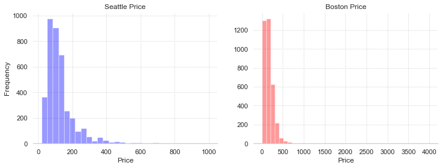

```python
sea_price = sea_df_nostd.price.copy()
bos_price = bos_df_nostd.price.copy()

fig, (ax1, ax2) = plt.subplots(1, 2, figsize=(12, 4))
sea_price.hist(bins=30, color='blue', alpha=0.4, ax=ax1)
bos_price.hist(bins=40, color='red', alpha=0.4, ax=ax2)
sns.despine(top=True, right=True, left=True)

ax1.set_title('Seattle Price')
ax2.set_title('Boston Price')
ax1.set_ylabel('Frequency')
ax1.set_xlabel('Price')
ax2.set_xlabel('Price')
```

Due to the scale issue, it is hard to compare two distributions. Therefore, let us transform price to log-price

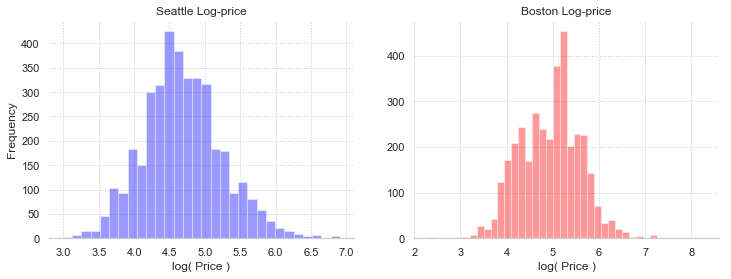

```python
## Transform price to log-price
sea_price = sea_price.map(lambda x: np.log(x))
bos_price = bos_price.map(lambda x: np.log(x))

## Visualize again
fig, (ax1, ax2) = plt.subplots(1, 2, figsize=(12, 4))
sea_price.hist(bins=30, color='blue', alpha=0.4, ax=ax1)
bos_price.hist(bins=40, color='red', alpha=0.4, ax=ax2)
sns.despine(top=True, right=True, left=True)

ax1.set_title('Seattle Log-price')
ax2.set_title('Boston Log-price')
ax1.set_ylabel('Frequency')
ax1.set_xlabel('log( Price )')
ax2.set_xlabel('log( Price )');
```

```python
## display statistics
_ = pd.concat([sea_price.describe(), bos_price.describe()], axis=1)
_.columns = ['Seattle log-price', 'Boston log-price']
_
```

|  | Seattle log-price | Boston log-price |
| --- | --- | --- |
| count | 3818.000000 | 3585.000000 |
| mean | 4.679227 | 4.940808 |
| std | 0.565525 | 0.652393 |
| min | 2.995732 | 2.302585 |
| 25% | 4.317488 | 4.442651 |
| 50% | 4.605170 | 5.010635 |
| 75% | 5.010635 | 5.393628 |
| max | 6.907755 | 8.294050 |

We can observe that Boston price is in general higher and is more spread out. Seattle log-price distribution shows symmetric aspect while Boston log-price distribution seems slightly left-skewed implying that Boston rental price is formed high. According to [Trulia](https://www.trulia.com/), this results corresponds to median rent per month. On average, Boston's median rent per month now is formed around \$2,900 and on contrary, Seattle's is around \\$2,700. Therefore, this results should come as no surprise. However, what is interesting is that medians sales price shows the opposite trend in two cities: median sales price of real estate is on average \$690,000 in Seattle, and is \\$610,000 in Boston. Using the concept of price to rent ratio, we achieve 17.53 for Boston and 21.30 for Seattle. As a general rule of thumb, if the ratio is from 16 to 20, then it is risky to buy a property and if it is 21+, it is much better to rent than buy. Therefore, it seems Boston is a more promising place to buy a house.

## Q2. How many Airbnb properties are hosted by the same host on average?

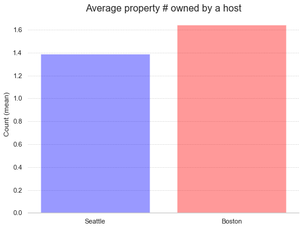

```python
## seattle
sea_host = sea_df_nostd.groupby('host_id').count()['id']
sea_host.name = 'property_count'
## boston
bos_host = bos_df_nostd.groupby('host_id').count()['id']
bos_host.name = 'property_count'

## Visualization
plt.figure(figsize=(8, 6))
ax = plt.subplot()
ax.bar(['Seattle', 'Boston'], [sea_host.mean(), bos_host.mean()], color=['blue', 'red'], alpha=0.4)
sns.despine(top=True, right=True, left=True)
ax.xaxis.grid(False)
plt.title("Average property # owned by a host", fontsize=16)
plt.ylabel('Count (mean)');
```

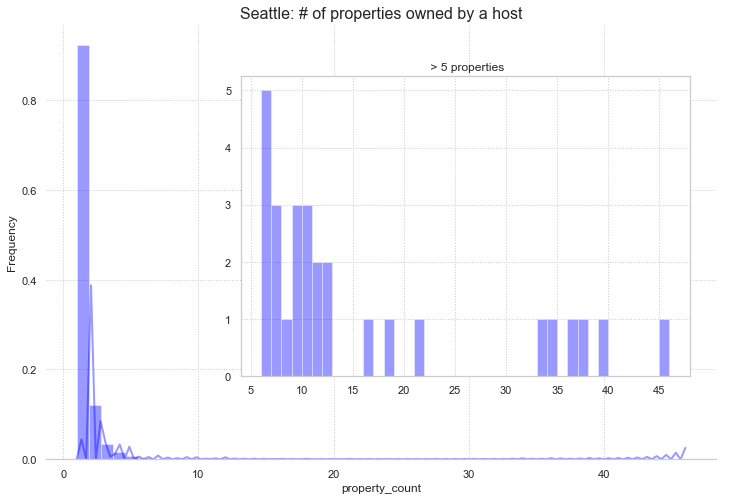

```python
fig = plt.figure(figsize=(12,8))
ax = sns.distplot(sea_host, color='blue', hist_kws={'alpha':0.4}, kde_kws={'alpha':0.4})
plt.title('Seattle: # of properties owned by a host', fontsize=16)
plt.ylabel('Frequency')
sns.despine(top=True, right=True, left=True)

## set inner plot
rect = [0.35, 0.27, 0.52, 0.52]
ax2 = fig.add_axes(rect)
sns.distplot(sea_host[sea_host>5], bins=40, ax=ax2, kde=False, color='blue', kde_kws={'alpha':0.4})
ax2.set_title(" > 5 properties")
ax2.set_xlabel('')

## add host property number info feature
sea_df['host_has'] = sea_df.groupby('host_id').transform('count')['id'].values
# sea_df = sea_df.drop(columns=['host_id'])

## standardize it
sea_df['host_has'] = scaler.fit_transform(sea_df[['host_has']])
```

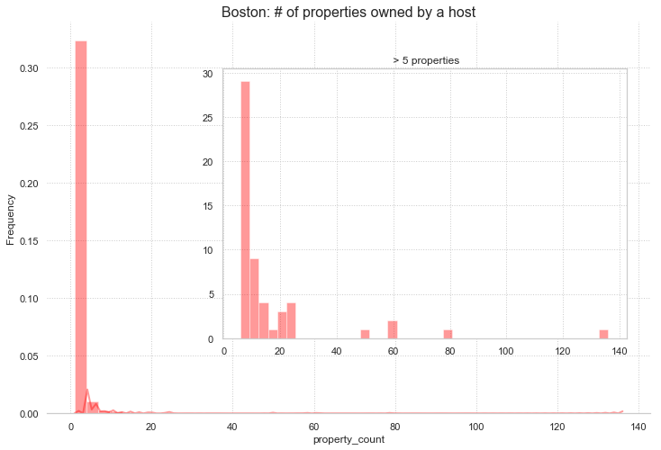

```python
fig = plt.figure(figsize=(12,8))
ax = sns.distplot(bos_host, color='red', hist_kws={'alpha':0.4}, kde_kws={'alpha':0.4})
plt.title('Boston: # of properties owned by a host', fontsize=16)
plt.ylabel('Frequency')
sns.despine(top=True, right=True, left=True)

## set inner plot
rect = [0.35, 0.27, 0.52, 0.52]
ax2 = fig.add_axes(rect)
sns.distplot(bos_host[bos_host>5], bins=40, ax=ax2, kde=False, color='red', kde_kws={'alpha':0.4})
ax2.set_title(" > 5 properties")
ax2.set_xlabel('')

## add host property number info feature
bos_df['host_has'] = bos_df.groupby('host_id').transform('count')['id'].values
# bos_df = bos_df.drop(columns=['host_id'])

## standardize it
bos_df['host_has'] = scaler.fit_transform(bos_df[['host_has']])
```

We see that on average, hosts in Boston own more Airbnb properties. This might imply that fewer hosts determine the price of Airbnb properties. Looking at individual distributions, we can confirm that there are more 'super' hosts in Boston. Therefore, we can suppose those "super" users set Airbnb prices higher in Boston.

## Q3. How does price spread based on location - is it evenly distributed or unevenly?

I will use 'zipcode' as a proxy for location information.

```
Standard Deviation is: 0.030
```

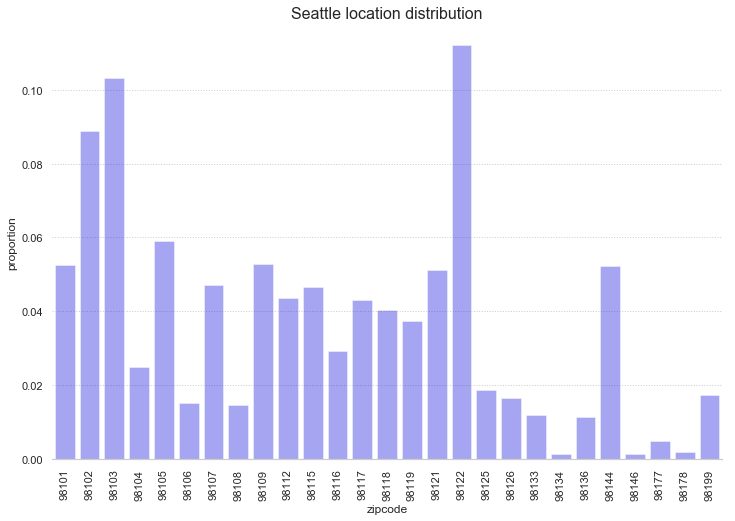

```python
sea_zip = pd.DataFrame(sea_df_nostd.groupby('zipcode').count()['id'])
sea_zip = sea_zip.reset_index()
sea_zip.columns = ['zipcode', 'proportion']
sea_zip['proportion'] /= len(sea_df)

## visualize it
fig = plt.figure(figsize=(12,8))
ax = sns.barplot(x='zipcode', y='proportion', data=sea_zip, color='blue', alpha=0.4)
plt.xticks(rotation=90)
plt.title("Seattle location distribution", fontsize=16)
sns.despine(top=True, right=True, left=True)

## print it
print("Standard Deviation is: {:.3f}".format(sea_zip.proportion.std()))

## add location frequency info feature
sea_df['zip_has'] = sea_df.groupby('zipcode').transform('count')['id'].values
# sea_df = sea_df.drop(columns=['zipcode'])

## standardize it
sea_df['zip_has'] = scaler.fit_transform(sea_df[['zip_has']])
```

```
Standard Deviation is: 0.028
```

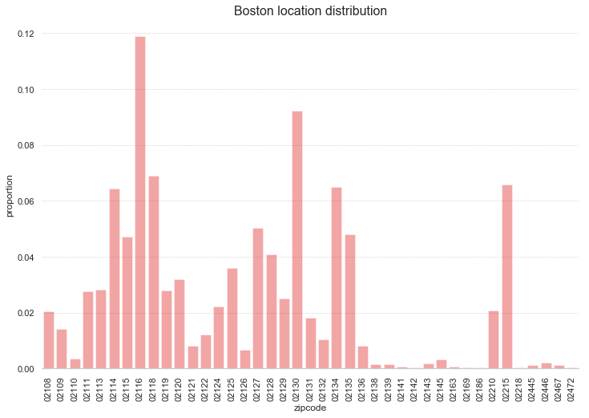

```python
bos_zip = pd.DataFrame(bos_df_nostd.groupby('zipcode').count()['id'])
bos_zip = bos_zip.reset_index()
bos_zip.columns = ['zipcode', 'proportion']
bos_zip['proportion'] /= len(bos_df)

## visualize it
fig = plt.figure(figsize=(12,8))
ax = sns.barplot(x='zipcode', y='proportion', data=bos_zip, color='red', alpha=0.4)
plt.xticks(rotation=90)
plt.title("Boston location distribution", fontsize=16)
sns.despine(top=True, right=True, left=True)

## print it
print("Standard Deviation is: {:.3f}".format(bos_zip.proportion.std()))

## add location info feature
bos_df['zip_has'] = bos_df.groupby('zipcode').transform('count')['id'].values
# bos_df = bos_df.drop(columns=['zipcode'])

## standardize it
bos_df['zip_has'] = scaler.fit_transform(bos_df[['zip_has']])
```

When it comes to the degree of the spread, the location distributions of two cities do not show much difference according to standard deviation. When we compare the distributions against rent maps ([Seattle](https://raw.githubusercontent.com/soo-pecialist/Udacity_Nanodegrees/master/Data%20Scientist/04_Data_Scientist_Blogging/image/Seattle_rent.png) and [Boston](https://raw.githubusercontent.com/soo-pecialist/Udacity_Nanodegrees/master/Data%20Scientist/04_Data_Scientist_Blogging/image/Boston_rent.png)) from [Trulia](https://www.trulia.com/), high proportion locations correspond to high rent areas; therefore have a higher impact on price distribution.

[output not shown]

All in all, we can conclude that most Airbnb properties are crowded at the hotspots of the cities.

# 4. Model Data

### Train model

Before we model the data, let us merge two dataframes and add the indicator of where they are from - Boston or Seattle.

```python
## Add indicator
sea_df['Seattle'] = 1
sea_df['Boston'] = 0
bos_df['Seattle'] = 0
bos_df['Boston'] = 1

## concatenate data frames
df = pd.concat([sea_df, bos_df], axis=0)
df = df.reset_index(drop=True)
```

```python
df.head(3)
```

|  | id | host_id | zipcode | price | bathrooms | bedrooms | beds | guests_included | extra_people | minimum_nights | ... | cancellation_policy_strict | cancellation_policy_super_strict_30 | require_guest_profile_picture_f | require_guest_profile_picture_t | require_guest_phone_verification_f | require_guest_phone_verification_t | host_has | zip_has | Seattle | Boston |
| --- | --- | --- | --- | --- | --- | --- | --- | --- | --- | --- | --- | --- | --- | --- | --- | --- | --- | --- | --- | --- | --- |
| 0 | 241032 | 956883 | 98119 | 85.0 | -0.438461 | -0.348068 | -0.645342 | 0.249756 | -0.322324 | -0.083987 | ... | 0 | 0 | 0 | 0 | 0 | 0 | -0.143034 | -0.72449 | 1 | 0 |
| 1 | 953595 | 5177328 | 98119 | 150.0 | -0.438461 | -0.348068 | -0.645342 | -0.513098 | -0.606680 | -0.022651 | ... | 1 | 0 | 0 | 0 | 0 | 0 | 0.193098 | -0.72449 | 1 | 0 |
| 2 | 3308979 | 16708587 | 98119 | 975.0 | 5.500872 | 4.183643 | 4.621311 | 6.352583 | 0.815098 | 0.100020 | ... | 0 | 0 | 0 | 0 | 0 | 0 | -0.255078 | -0.72449 | 1 | 0 |

3 rows × 138 columns

```python
## split into response and predictors, train and test data
X = df.drop(columns=['id', 'host_id', 'zipcode', 'price'])
y = df['price']
X_train, X_test, y_train, y_test = train_test_split(X, y, test_size=0.25, random_state=777)
```

```python
## **** helper.model_data(sea_df, bos_df, random_state=77) ****

## convert the dataset into an optimized data structure called Dmatrix that XGBoost supports
data_dmatrix = xgb.DMatrix(data=X_train, label=y_train, feature_names=X_train.columns)

## parameter dictionary holder
params = []

## candidate parameters
max_depths = [3, 4, 5]
gammas = [0, 0.1, 0.5, 1, 5]
learning_rates = [0.05, 0.1, 0.5]
subsamples = [0.7, 0.8, 1]
reg_lambdas = [0.5, 1, 5, 10]
colsample_bytrees = [0.7, 0.8, 1]

## manually grid search cv
for max_depth in max_depths:
    for gamma in gammas:
        for learning_rate in learning_rates:
            for subsample in subsamples:
                for reg_lambda in reg_lambdas:
                    for colsample_bytree in colsample_bytrees:
                        ## define hyper parameters for xgbregressor
                        param = dict(max_depth=max_depth,
                                           gamma=gamma,
                                           learning_rate=learning_rate,
                                           subsample = subsample,
                                           reg_lambda=reg_lambda,
                                           colsample_bytree=colsample_bytree)
                        ## retrieve cv results dataframe
                        cv_results = xgb.cv(dtrain=data_dmatrix, params=param, nfold=5,
                                            num_boost_round=50, early_stopping_rounds=20,
                                            metrics="rmse", as_pandas=True, seed=(777*29)%10000)
                        cv_score = cv_results["test-rmse-mean"].iloc[-1]
                        ## append the score and parameters to params
                        params.append((cv_score, param))


## get best parameters that gives lowest validation rmse score
params = sorted(params, key=lambda x: x[0])
best_params = params[0][1]
best_valid_score = params[0][0]

## train the model with best parameters
xgb_reg = xgb.XGBRegressor(max_depth=best_params['max_depth'], gamma=best_params['gamma'],
                           learning_rate=best_params['learning_rate'], subsample=best_params['subsample'],
                           reg_lambda=best_params['reg_lambda'], colsample_bytree=best_params['colsample_bytree'],
                           n_estimators = 100)
xgb_reg.fit(X_train, y_train)

## print out results
print("======= CV Result =======")
print("> best validation score: {:.4f}".format(best_valid_score))
print("> Best hyper parameters:")
print("  ", best_params)
```

```
======= CV Result =======
> best validation score: 97.7722
> Best hyper parameters:
   {'max_depth': 5, 'gamma': 0, 'learning_rate': 0.1, 'subsample': 1, 'reg_lambda': 1, 'colsample_bytree': 0.7}
```

```python
# ## *** you can run this code to train model. This will do the above precedures in 'model data'
# xgb_reg, X_train, X_test, y_train, y_test = model_data(sea_df, bos_df, random_state=777)
```

### Predict responses

```python
## **** helper.predict_model(xgb_reg, X_test, y_test, show=False, number=10) ****
## predict
y_hat = xgb_reg.predict(X_test)

## evaluate on test data
r2 = r2_score(y_test, y_hat)
rmse = np.sqrt(mean_squared_error(y_test, y_hat))

print("======= Result =======")
print("> test r-squared: {:.4f}".format(r2))
print("> test RMSE: {:.4f}".format(rmse))
```

```
======= Result =======
> test r-squared: 0.5058
> test RMSE: 78.0201
```

```python
## Let us see 10 random picked true price values and predicted price values
compare_df = pd.DataFrame({'y_test': y_test, 'y_hat': y_hat})
ind = np.random.choice(len(compare_df), 10, replace=False)
compare_df.iloc[ind]
```

|  | y_test | y_hat |
| --- | --- | --- |
| 4113 | 275.0 | 250.155304 |
| 6156 | 120.0 | 131.251282 |
| 2366 | 50.0 | 75.948936 |
| 4171 | 180.0 | 217.426910 |
| 3217 | 85.0 | 82.773048 |
| 1120 | 129.0 | 136.373596 |
| 3130 | 149.0 | 190.805786 |
| 548 | 135.0 | 172.751205 |
| 5846 | 200.0 | 126.002937 |
| 3752 | 160.0 | 149.845459 |

### Q4. What are the most important predictors for the price?

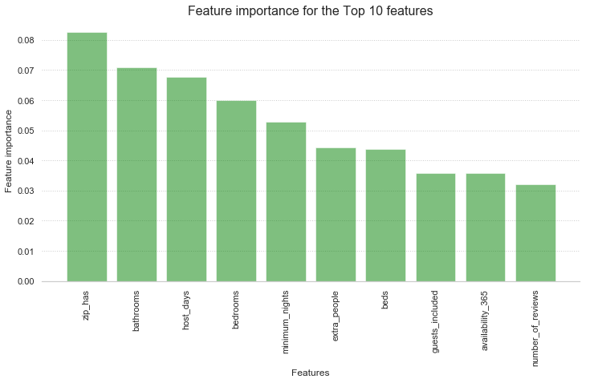

```
Top 10 important features:
 ['zip_has', 'bathrooms', 'host_days', 'bedrooms', 'minimum_nights', 'extra_people', 'beds', 'guests_included', 'availability_365', 'number_of_reviews']
```

```python
## visualize it
features = sorted(zip(xgb_reg.feature_importances_, X_train.columns), reverse=True)
attr = []
coef = []
number = 10

for feature in features:
    attr.append(feature[1])
    coef.append(feature[0])

plt.figure(figsize=(12,6))
ax = plt.subplot()
ax.bar(attr[:number], height=coef[:number], color='green', alpha=0.5)
sns.despine(top=True, right=True, left=True)
ax.xaxis.grid(False)
plt.xticks(rotation=90)
plt.xlabel('Features')
plt.ylabel('Feature importance')
plt.title('Feature importance for the Top {} features'.format(number), fontsize=16)
plt.show()

## print features
print("Top {} important features:\n {}".format(number, attr[:number]))
```

```python
# ## *** you can run this code to predict responses. This will do the above prediction procedures
# preds, rmse = predict_model(xgb_reg, X_test, y_test, show=False, number=10)
```

You can see that your test RMSE (Root Mean Square Error) has reduced as compared to validation RMSE and came out to be around 78.0201 per \$1,000, which is promising - it means the model performed better in the wild than practice. When we see In[61], the predicted prices are not too far off of actual prices.

Now, we obtained top 10 features of importance which goes:

- zip_has: number of Airbnb properties in the location of the zip codes. An indicator of how busy the location is.
- bathrooms: number of bathrooms.
- host_days: days that host has been hosting Airbnb properties.
- bedrooms: number of bedrooms.
- minimum_nights: minimum nights you need to book for.
- extra_people: extra fee for more guests than the host set.
- beds: number of beds
- guests_included: number of guests Airbnb property can hold.
- availability_365: number of days available in a year.
- number_of_reviews: number of reviews.

If you see the list above, it seems natural that they play an important role to predict price. First, if the place is a busy place such as tourist sight, there should be more demand for accommodations; thus increasing the price. The number of bathroom, bedroom, and bed reflects the level of comfort. No one would prefer to wait in line before the bathroom or sleep on the couch. If you have been hosting of Airbnb property quite a long time, you should know how the market fluctuates. From a data science perspective, you are more predictable because you are more likely to lead the market trend than a fresh host. Minimum nights, extra guest fee, and maximum guests number are rules set by the hosts and factored directly into the calculation for the price. Therefore, it is convincing that these two factors are ranked high. Lastly, the number of days available in a year and the number of reviews reflects the popularity of an Airbnb property. Naturally, high demand leads to a higher price.

### Conclusion

In this project, we delved in the 2016 Seattle and Boston Airbnb dataset and found some interesting patterns.

1. Boston is a more expensive city to travel with Airbnb. This phenomenon complies with the current median rent per month trend in two cities - Boston is more expensive to rent a property.
2. Hosts in Boston own more Airbnb properties on average and there are more 'super' hosts. Therefore, we might imply that a few super hosts can sway average price in the city.
3. High proportion locations correspond to high rent areas in both Seattle and Boston. Therefore, we may assume rent, location, and Airbnb price are closely related.
4. From important features, we know that popularity, location, level of comfort, and property rules impact on the Airbnb price.

This project set out with questions such as if there is a difference in price in two cities, how prices spread based on location, and what the most import predictors are. Hopefully, this project answered questions and provide you insights of what can influence Airbnb price. I believe this model can provide customers with information on the travel budget and plan, and hosts with reference to set a price for their properties.